# Standardized Qualitative Analysis of Dynamics (squad) R package

During the definition of a regulatory network model it is frequently convenient to start with simple formalisms and then to transit to more refined models. Continuous interpolations of Boolean Regulatory Networks (BRN) are defined so as to preserve dynamical characteristics of discrete model but extending the range of values of the variables. In this tutorial we presented the main features of the squad R package to simulate continuous interpolations of BRN models.

squad R package is a useful tool to define, set up and run simulations using continuous interpolations of regulatory network models. It also can perform stationary states search.

#### **1. Overview of squad R package**

The next figure shows schematically the main features of the squad R package. squad extends the functionality of the BoolNet R package. BoolNet has integrated an optimized method to find synchronous stable states by using the Dubrova algorithm. By the other hand, in an asynchronous context SQUAD performs an optimized heuristic method using BDD representations and model checking. Hence, the modeller can start defining a discrete BRN model and choose synchronous or asynchronous efficient methods for stationary states search.

Additionally, if needed the modeler can transit to more refined continuous methods as the squad or normalized Hill Cubes interpolations of BRN models.

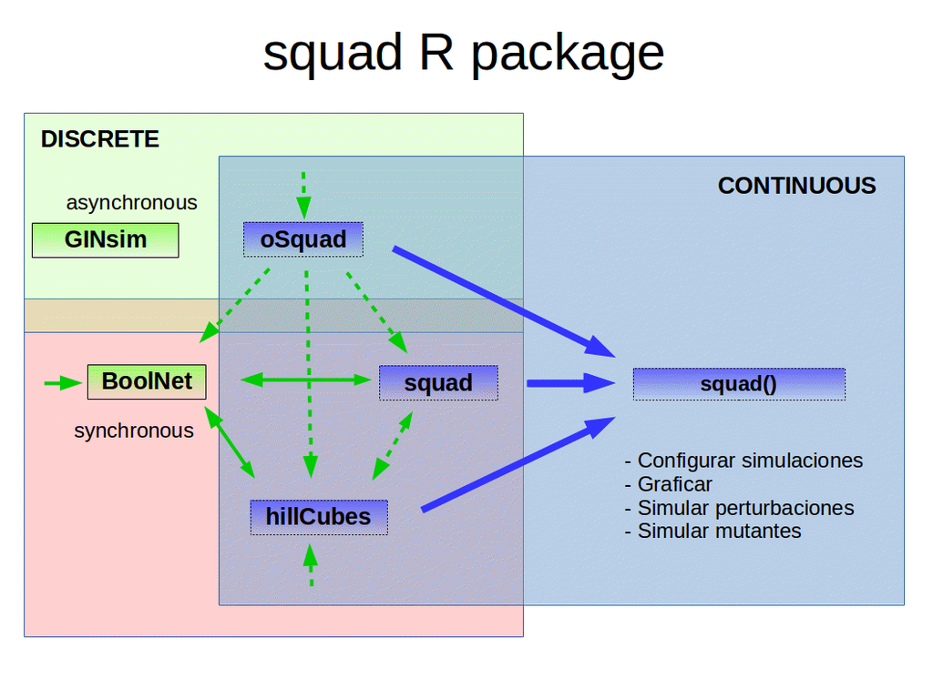

The main methods of squad R package are

- squad() sets up initial states and parameters, and also runs simulations.
- getAttractors.sq() calculates stationary states of the model.
- asContinuous() allows to transform Boolean models to continuous interpolations

#### **2. Instaling SQUAD**

SQUAD uses the following dependencies:

- BoolNet
- deSolve
- reshape
- ggplot2

These can be installed automatically by setting depencies=TRUE or manually. Some of these packages may require the instalation of curl and XML libraries. To instal the SQUAD R package please run the following command inside R.

```r
library(devtools)
# temporary loading from github
install_github("caramirezal/SQUAD/SQUAD")
```

#### **3. Defining and running simulations using squad format**

To define a Regulatory Network using squad formalism it is necessary define a set of variables nodes and also include the regulatory dependencies between them. In squad formalism the regulatory dependencies are incorporated to the ordinary differential equations in the form of the $omega$ input parameter. The expression are similar to the Boolean expression of the BRN model and can be obtained from them straightforwardly by changing Boolean operators AND, OR, and NOR by the fuzzy logic operators $min()$, $max()$ and $1 - x$ (where x is the value of the input).

Nodes names and their dependencies can be given by using the squad format. This format is very similar to BoolNet format, see [BoolNet R Package](https://academic.oup.com/bioinformatics/article/26/10/1378/193238/BoolNet-an-R-package-for-generation-reconstruction) for further references. Here, we show the content of a file in squad format called cartoonNetworkSQUAD.txt.

`targets, factors`

`A, A`

`B, min(A,1-C)`

`C, 1 - max(A,B)`

The squad format consist of a text file that includes in the first line the headers “targets, factors” and in the following lines the names of the variables and the fuzzy logic equations of the $ommga$ input function separated by a comma. So, for example, The node B has as parameter $w = min(A,1-C)$. This format can be imported to squad R package by using loadNetwork.sq() as in the following example.

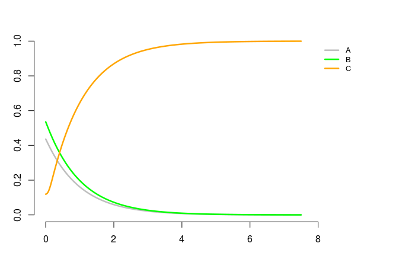

```r
net.sq <- loadNetworkSQUAD("cartoonNetworkSQUAD.txt")
sim <- squad(net.sq)
timeSerie.sq(sim)
```

The figure shows the dynamic of single trajectory starting as default from a random initial state of the network consisting of the three nodes defined above.

#### **4. Starting with a discrete BRN model**

As mentioned aboved, BRN are parameters free simple models which emphasizes in the study of the dynamics driven by the combinatory of values of the regulators that determines the levels of activations of the nodes in the network. In practice, it is usually convenient to start with such a simple approach and then transit to more complex formalism if needed. The squad R package can be used in combination with BoolNet to acomplish this task as follows.

We will use here a BRN model available in the BoolNet R package. The model contains key regulators of the mammalian cell cycle.

```r
library(BoolNet)
library(SQUAD)
data("cellcycle")
cellcycle
```

```
Boolean network with 10 genes

Involved genes:
CycD Rb E2F CycE CycA p27 Cdc20 Cdh1 UbcH10 CycB

Transition functions:
CycD = CycD
Rb = (! CycA & ! CycB & ! CycD & ! CycE) | (p27 & ! CycB & ! CycD)
E2F = (! Rb & ! CycA & ! CycB) | (p27 & ! Rb & ! CycB)
CycE = (E2F & ! Rb)
CycA = (E2F & ! Rb & ! Cdc20 & ! (Cdh1 & UbcH10)) | (CycA & ! Rb & ! Cdc20 & ! (Cdh1 & UbcH10))
p27 = (! CycD & ! CycE & ! CycA & ! CycB) | (p27 & ! (CycE & CycA) & ! CycB &! CycD)
Cdc20 = CycB
Cdh1 = (! CycA & ! CycB) | (Cdc20) | (p27 & ! CycB)
UbcH10 = ! Cdh1 | (Cdh1 & UbcH10 & (Cdc20 | CycA | CycB))
CycB = ! Cdc20 & ! Cdh1
```

The cellcycle object belongs to the “BooleanNetwork” class as defined by the BoolNet R package. Using the asContinuous() of squad R package function this object can be automatically transformed to a continuous interpolation of BRN models. In the next example, cellcyle “BooleanNetwork” object is transformed to a cellcycle.sq “squad” object.

```r
#  cellcycle "BooleanNetwork" transformation to cellcycle.ci "squad" object
cellcycle.sq <- asContinuous(cellcycle)
class(cellcycle.sq)
```

```
[1] "squad"
```

We will use this new model object to perform a simulation using squad(). The squad() function will be described more deeply in following sections in this case we will use default parameters.

```r
initialState <- rep(0,length(cellcycle$genes))
sim <- squad(cellcycle.sq,initialState = initialState)
head(sim)
```

```
     time CycD          Rb         E2F         CycE         CycA         p27        Cdc20        Cdh1      UbcH10
[1,] 0.00    0 0.000000000 0.000000000 0.000000e+00 0.000000e+00 0.000000000 0.000000e+00 0.000000000 0.000000000
[2,] 0.01    0 0.009950248 0.009950248 4.455076e-14 4.455076e-14 0.009950248 4.455076e-14 0.009950248 0.009950248
[3,] 0.02    0 0.019801489 0.019801489 2.055319e-13 2.055319e-13 0.019801489 2.055319e-13 0.019801489 0.019801489
[4,] 0.03    0 0.029554708 0.029554708 5.541270e-13 5.541270e-13 0.029554708 5.541270e-13 0.029554708 0.029554708
[5,] 0.04    0 0.039210759 0.039210759 1.188807e-12 1.188807e-12 0.039210759 1.188807e-12 0.039210759 0.039210759
[6,] 0.05    0 0.048770771 0.048770771 2.302742e-12 2.302742e-12 0.048770771 2.302742e-12 0.048770771 0.048770771
            CycB
[1,] 0.000000000
[2,] 0.009950248
[3,] 0.019801489
[4,] 0.029554708
[5,] 0.039210759
[6,] 0.048770771
```

In this example, we started the simulation with a initial state with all genes OFF. The output of squad() is a raw matrix with the values of a single trajectory starting from that initial conditions.

We can also transform a BRN model to a continuous interpolation using normalized Hill Cubes formalism. The asContinuous() squad R package function can also achieve this purpose by setting the argument to = “normHillCubes”.

```r
cellcycle.ci <- asContinuous(cellcycle,to="normHillCubes")
initialState <- rep(0,length(cellcycle$genes))
sim <- squad(cellcycle.ci,initialState = initialState)
head(sim)
```

```
     time CycD          Rb         E2F         CycE         CycA         p27        Cdc20        Cdh1      UbcH10
[1,] 0.00    0 0.000000000 0.000000000 0.000000e+00 0.000000e+00 0.000000000 0.000000e+00 0.000000000 0.000000000
[2,] 0.01    0 0.009950248 0.009950248 5.897833e-88 5.897833e-88 0.009950248 5.897833e-88 0.009950248 0.009950248
[3,] 0.02    0 0.019801489 0.019801489 4.421316e-73 4.421316e-73 0.019801489 4.421316e-73 0.019801489 0.019801489
[4,] 0.03    0 0.029554708 0.029554708 2.085279e-64 2.085279e-64 0.029554708 2.085279e-64 0.029554708 0.029554708
[5,] 0.04    0 0.039210759 0.039210759 2.326761e-58 2.326761e-58 0.039210759 2.326761e-58 0.039210759 0.039210759
[6,] 0.05    0 0.048770771 0.048770771 1.252084e-53 1.252084e-53 0.048770771 1.252084e-53 0.048770771 0.048770771
            CycB
[1,] 0.000000000
[2,] 0.009950248
[3,] 0.019801489
[4,] 0.029554708
[5,] 0.039210759
[6,] 0.048770771
```

In following sections we will describe the use of plotSequence.sq() to generate time series as curve plots or heatmaps instead of have to deal with raw matrix data.

#### **5. Calculation of steady states**

A was mentioned above the squad R package incorporates the method for steady states SS search as implemented by [GINsim](http://ginsim.org/). To appreciate better the performance of the method we will use a network with 100 nodes and calculate a single trajectory simulation along with a SS search. A random model will be defined with the help of [BoolNet R Package](https://academic.oup.com/bioinformatics/article/26/10/1378/193238/BoolNet-an-R-package-for-generation-reconstruction).

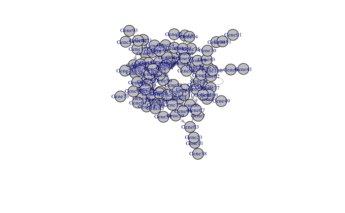

```r
# loading the Boolean model
bigNet <- generateRandomNKNetwork(n=100,k=20,topology = "scale_free",simplify = T)
# plotting the BRN topology
plotNetworkWiring(bigNet)
```

The BRN model has been initialized with 100 nodes.

[output not shown]

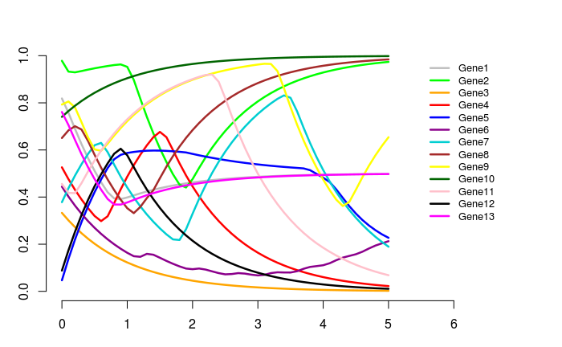

```r
# transforming the model to a continuous formalism using SQUAD
net.squad <- asContinuous(bigNet)
# simulating a network trajectory
sim <- squad(net.squad,timePeriod = 5,lengthInterval = 0.1)
timeSerie.sq(sim)
```

The figure shows a single trajectory of the network. Parameters are fixed to default which are $beta = 1$ and $gamma = 50$ in every ODE function. As can be seen only the curves for the first 13 genes were plotted although a vector of indexes (of lenght no bigger than 13) can be passed as argument to choose which genes are to be plotted.

We exemplify here the calculation of steady states (SS) attractors calculated in the asynchronous updating regimen. To perform the SS searcher in a synchronous context based in the Dubrova algorithm, please see [BoolNet](https://cran.r-project.org/web/packages/BoolNet/index.html) documentation.

```r
att <- getAttractors.sq(net.bool)
```

```
The transition functions of this network did not contain valid symbolic expressions! Generating DNF representations from the truth tables!
```

```
FINISHED
nrow 3
ncol 100
```

```r
str(att)
```

```
'data.frame':   100 obs. of  3 variables:
 $ Attr.1: num  0 0 1 1 1 0 0 0 1 0 ...
 $ Attr.2: num  0 0 1 1 1 0 1 0 0 0 ...
 $ Attr.3: num  1 1 1 0 0 1 1 1 0 0 ...
```

As can be seen the method the network have 3 attractors. getAttractors.sq() can be used to find SS from large networks in a very efficient way. In fact, the methods for finding SS are faster than the methods to perform single trajectories!